# Activity 12

NHUNG NGUYEN

2023-10-19

**1. Merge the Clinical Dataset with the SVI dataset.**

```r
DATA = merge(Clinicaldatawoo , SVI_noID, by.x = "pseudocounty", by.y =  "pseudoSTCNTY")
```

**2. Get the 4 variables from your Well defined problem, and use the select function to keep only those in the dataset. Your new dataset should have only those.**

```r
Selected_DATA <- DATA %>% select(psychipr,rel,intxrel,intxsurv)

head(Selected_DATA, 4)
```

```
##   psychipr rel intxrel intxsurv
## 1        0   0   2.138    2.138
## 2        0   1  45.493   74.704
## 3        0   0  86.711   86.711
## 4        0   0  12.796   12.796
```

**3. One of your variables should be changed so that it is not used exactly as given (for example - filtered or mutated). Create a new variable in the dataset in the dataset that represents the changed variable.**

```r
Filtered = Selected_DATA  %>%  filter(psychipr == "1")

head (Filtered,5)
```

```
##   psychipr rel intxrel intxsurv
## 1        1   0  58.717   58.717
## 2        1   1   0.033    2.796
## 3        1   1   6.941   12.730
## 4        1   0   1.316    1.316
## 5        1   0  13.026   13.026
```

**Well-defined problem:** Do psychiatric disturbance (psychipr) and relaspe conditions (relapse history (rel) and time from HCT to relapse (intxrel)) affect the interval between transplant and survival date (intsxurv) ?

```r
write.csv(Filtered,"Filtered.csv")
```

```r
Filtered %>%
  group_by(`rel`, `psychipr`)%>%
  summarise(`Maximum_time_HCT`= max(`intxrel`),
            `Minimum_time_HCT` = min(`intxrel`),
            `Mean_time_HCT` = mean(`intxrel`, na.rm=TRUE),
            `Median_time_HCT` = median(`intxrel`, na.rm=TRUE))
```

[output not shown]

```
## # A tibble: 3 × 6
## # Groups:   rel [3]
##     rel psychipr Maximum_time_HCT Minimum_time_HCT Mean_time_HCT Median_time_HCT
##   <dbl>    <dbl>            <dbl>            <dbl>         <dbl>           <dbl>
## 1     0        1             122.            0.033          33.5           24.1
## 2     1        1             116.            0.033          10.2            5.67
## 3    99        1              NA            NA             NaN             NA
```

```r
Filtered %>%
  group_by(`rel`, `psychipr`)%>%

  summarise(`Maximum_interval`= max(`intxsurv`),
            `Minimum_interval` = min(`intxsurv`),
            `Mean_interval` = mean(`intxsurv`, na.rm=TRUE),
            `Median_interval` = median(`intxrel`, na.rm=TRUE))
```

[output not shown]

```
## # A tibble: 3 × 6
## # Groups:   rel [3]
##     rel psychipr Maximum_interval Minimum_interval Mean_interval Median_interval
##   <dbl>    <dbl>            <dbl>            <dbl>         <dbl>           <dbl>
## 1     0        1           122.              0.033         33.5            24.1
## 2     1        1           118.              0.954         21.4             5.67
## 3    99        1             5.46            5.46           5.46           NA
```

**6.Create 1 barplot that addresses 2-3 variables in your well-defined problem.** **a. The variable that you want to “predict” should be included.** **b. Make sure the plot has a title. Use the layer: +ggtitle(“Title You Want”)**

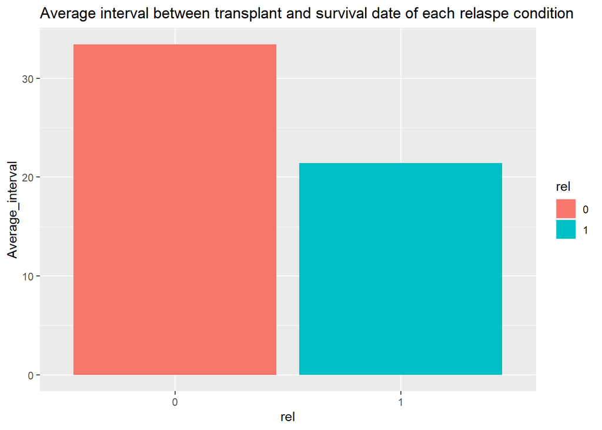

```r
Filtered %>%
  mutate(rel = as.factor(rel))%>%
  filter(rel %in% c("1","0")) %>%
  group_by(rel)%>%
  summarise(Average_interval = mean(intxsurv), .groups = "drop") %>%
  ggplot(aes(x = rel, y = Average_interval, fill = rel)) +
  geom_bar(stat = 'identity', position = "dodge")+
  ggtitle("Average interval between transplant and survival date of each relaspe condition")
```